# Covid Dataset

```python
import pandas as pd
import pandasql
pysqldf = lambda q: sqldf(q, globals()) #Should have included this from the begening
import numpy as np
import requests
import matplotlib.pyplot as plt
import datetime
```

```python
np.__version__
```

```
'1.19.2'
```

```python
# Importing the dataset from github
# Hasell, J., Mathieu, E., Beltekian, D. et al. A cross-country database of COVID-19 testing. Sci Data 7, 345 (2020)

csvfile = "owid-covid-data.csv"
status = requests.get("https://covid.ourworldindata.org/data/owid-covid-data.csv")
status.raise_for_status()

with open(csvfile, "wb") as dataset:
    dataset.write(status.content)

print("Download of latest version complete, source: https://covid.ourworldindata.org/data/owid-covid-data.csv")

covidset = pd.read_csv("owid-covid-data.csv")
```

```
Download of latest version complete, source: https://covid.ourworldindata.org/data/owid-covid-data.csv
```

```python
# Starting to look at the data provided
type(covidset)
```

```
pandas.core.frame.DataFrame
```

```python
covidset.shape
```

```
(71894, 59)
```

```python
covidset.head()
```

|  | iso_code | continent | location | date | total_cases | new_cases | new_cases_smoothed | total_deaths | new_deaths | new_deaths_smoothed | ... | gdp_per_capita | extreme_poverty | cardiovasc_death_rate | diabetes_prevalence | female_smokers | male_smokers | handwashing_facilities | hospital_beds_per_thousand | life_expectancy | human_development_index |
| --- | --- | --- | --- | --- | --- | --- | --- | --- | --- | --- | --- | --- | --- | --- | --- | --- | --- | --- | --- | --- | --- |
| 0 | AFG | Asia | Afghanistan | 2020-02-24 | 1.0 | 1.0 | NaN | NaN | NaN | NaN | ... | 1803.987 | NaN | 597.029 | 9.59 | NaN | NaN | 37.746 | 0.5 | 64.83 | 0.511 |
| 1 | AFG | Asia | Afghanistan | 2020-02-25 | 1.0 | 0.0 | NaN | NaN | NaN | NaN | ... | 1803.987 | NaN | 597.029 | 9.59 | NaN | NaN | 37.746 | 0.5 | 64.83 | 0.511 |
| 2 | AFG | Asia | Afghanistan | 2020-02-26 | 1.0 | 0.0 | NaN | NaN | NaN | NaN | ... | 1803.987 | NaN | 597.029 | 9.59 | NaN | NaN | 37.746 | 0.5 | 64.83 | 0.511 |
| 3 | AFG | Asia | Afghanistan | 2020-02-27 | 1.0 | 0.0 | NaN | NaN | NaN | NaN | ... | 1803.987 | NaN | 597.029 | 9.59 | NaN | NaN | 37.746 | 0.5 | 64.83 | 0.511 |
| 4 | AFG | Asia | Afghanistan | 2020-02-28 | 1.0 | 0.0 | NaN | NaN | NaN | NaN | ... | 1803.987 | NaN | 597.029 | 9.59 | NaN | NaN | 37.746 | 0.5 | 64.83 | 0.511 |

5 rows × 59 columns

```python
#testing out using SQL to interact with the df

covsetsql = pandasql.sqldf("SELECT * FROM covidset LIMIT 5;", globals())
print(covsetsql)
```

```
  iso_code continent     location        date  total_cases  new_cases  \
0      AFG      Asia  Afghanistan  2020-02-24          1.0        1.0
1      AFG      Asia  Afghanistan  2020-02-25          1.0        0.0
2      AFG      Asia  Afghanistan  2020-02-26          1.0        0.0
3      AFG      Asia  Afghanistan  2020-02-27          1.0        0.0
4      AFG      Asia  Afghanistan  2020-02-28          1.0        0.0

  new_cases_smoothed total_deaths new_deaths new_deaths_smoothed  ...  \
0               None         None       None                None  ...
1               None         None       None                None  ...
2               None         None       None                None  ...
3               None         None       None                None  ...
4               None         None       None                None  ...

   gdp_per_capita  extreme_poverty cardiovasc_death_rate diabetes_prevalence  \
```

[output cut: 21 more lines]

```python
#using SQL to find more info on the dataset

continentsSQL = pandasql.sqldf("SELECT DISTINCT continent FROM covidset;", globals())
print(continentsSQL)
```

```
       continent
0           Asia
1           None
2         Europe
3         Africa
4  North America
5  South America
6        Oceania
```

```python
locationsql = pandasql.sqldf("SELECT DISTINCT location FROM covidset;")
print(locationsql)
```

```
        location
0    Afghanistan
1         Africa
2        Albania
3        Algeria
4        Andorra
..           ...
209      Vietnam
210        World
211        Yemen
212       Zambia
213     Zimbabwe

[214 rows x 1 columns]
```

```python
#Python ineffecient loop to find the continents

def casesbycont(df):
    continents = dict()
    for i, row in df.iterrows():
        cont = row['continent']
        ncases = row['new_cases']
        if cont in continents and cont is float:
            continents[cont] = contintents[cont] + ncases
        else:
            continents[cont] = ncases
    return continents

covidcasesbycont = casesbycont(covidset)
print(covidcasesbycont)
```

```
{'Asia': 16.0, nan: 283244.0, 'Europe': 0.0, 'Africa': 31.0, 'North America': 51204.0, 'South America': 377.0, 'Oceania': 0.0}
```

```python
#I want to clean out countries that have little data on them
someinfosql = pandasql.sqldf("SELECT * FROM covidset WHERE new_cases_smoothed IS NOT NULL")
someinfosql = pandasql.sqldf("SELECT * FROM someinfosql WHERE NOT location='World'")
print(someinfosql)
```

```
      iso_code continent     location        date  total_cases  new_cases  \
0          AFG      Asia  Afghanistan  2020-02-29          1.0        0.0
1          AFG      Asia  Afghanistan  2020-03-01          1.0        0.0
2          AFG      Asia  Afghanistan  2020-03-02          1.0        0.0
3          AFG      Asia  Afghanistan  2020-03-03          2.0        1.0
4          AFG      Asia  Afghanistan  2020-03-04          4.0        2.0
...        ...       ...          ...         ...          ...        ...
69527      ZWE    Africa     Zimbabwe  2021-02-24      35960.0       50.0
69528      ZWE    Africa     Zimbabwe  2021-02-25      35994.0       34.0
69529      ZWE    Africa     Zimbabwe  2021-02-26      36044.0       50.0
69530      ZWE    Africa     Zimbabwe  2021-02-27      36058.0       14.0
69531      ZWE    Africa     Zimbabwe  2021-02-28      36089.0       31.0

       new_cases_smoothed  total_deaths  new_deaths  new_deaths_smoothed  ...  \
0                   0.143           NaN         NaN                0.000  ...
```

[output cut: 64 more lines]

```python
#now I want the most recent date for each given country
mostrecent = pandasql.sqldf("SELECT * FROM someinfosql WHERE date=(SELECT MAX(date) FROM someinfosql) ")
print(mostrecent)
```

```
     iso_code      continent     location        date  total_cases  new_cases  \
0         AFG           Asia  Afghanistan  2021-02-28      55714.0        7.0
1    OWID_AFR           None       Africa  2021-02-28    3897307.0     9414.0
2         ALB         Europe      Albania  2021-02-28     107167.0      952.0
3         DZA         Africa      Algeria  2021-02-28     113092.0      132.0
4         AND         Europe      Andorra  2021-02-28      10866.0       17.0
..        ...            ...          ...         ...          ...        ...
193       VEN  South America    Venezuela  2021-02-28     139116.0      377.0
194       VNM           Asia      Vietnam  2021-02-28       2448.0       16.0
195       YEM           Asia        Yemen  2021-02-28       2285.0       16.0
196       ZMB         Africa       Zambia  2021-02-28      78534.0      332.0
197       ZWE         Africa     Zimbabwe  2021-02-28      36089.0       31.0

     new_cases_smoothed  total_deaths  new_deaths  new_deaths_smoothed  ...  \
0                15.714        2443.0         0.0                1.571  ...
```

[output cut: 51 more lines]

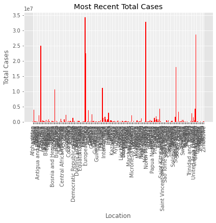

```python
#Now a bar chart of most recent total cases and new cases

plt.style.use('ggplot')

x = mostrecent["location"]
totalcases = mostrecent["total_cases"]

x_pos = [i for i, _ in enumerate(x)]

plt.bar(x_pos, totalcases, color='red')
plt.xlabel("Location")
plt.ylabel("Total Cases")
plt.title("Most Recent Total Cases")
plt.tight_layout()
plt.xticks(x_pos, x, rotation=90)

plt.show()
```

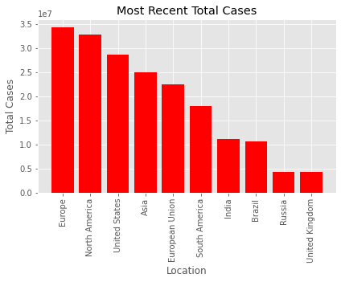

```python
#That graph looks a tad dense. I want to graph the top 10.

mostrecenttop = pandasql.sqldf("SELECT * FROM mostrecent ORDER BY total_cases DESC LIMIT 10")

plt.style.use('ggplot')

x = mostrecenttop["location"]
totalcases = mostrecenttop["total_cases"]

x_pos = [i for i, _ in enumerate(x)]

plt.bar(x_pos, totalcases, color='red')
plt.xlabel("Location")
plt.ylabel("Total Cases")
plt.title("Most Recent Total Cases")
plt.tight_layout()
plt.xticks(x_pos, x, rotation=90)

plt.show()
```

My Issue here is that continents are still being included. At first I wanted to remove rows that had a location which matched a name for a continent. I realized that an easy way to do it would instead to be just to not include the rows where the ISO code has more than 3 letters, as all country ISO codes are meant to be 3 letters.

```
   iso_code continent       location        date  total_cases  new_cases  \
0  OWID_AFR      None         Africa  2021-02-28    3897307.0     9414.0
1  OWID_ASI      None           Asia  2021-02-28   25022183.0    67989.0
2  OWID_EUR      None         Europe  2021-02-28   34263583.0    98276.0
3  OWID_NAM      None  North America  2021-02-28   32883403.0    59336.0
4  OWID_OCE      None        Oceania  2021-02-28      32717.0       10.0
5  OWID_SAM      None  South America  2021-02-28   17968065.0    48219.0

   new_cases_smoothed  total_deaths  new_deaths  new_deaths_smoothed  ...  \
0            9700.714      103706.0       225.0              338.571  ...
1           72326.714      398741.0       751.0              951.714  ...
2          134445.000      813971.0      1670.0             3042.429  ...
3           81074.429      746830.0      1650.0             2942.000  ...
4              53.857         949.0         0.0                0.286  ...
5           78810.286      466504.0      1019.0             1791.429  ...
```

[output cut: 26 more lines]

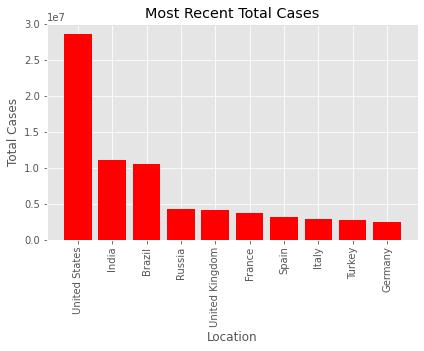

```python
#The values I want to remove
print(pandasql.sqldf("SELECT * FROM mostrecent WHERE location IN (SELECT * FROM continentsSQL)"))
#I figure the continent data may be useful for the future
continentsSQLdata = pandasql.sqldf("SELECT * FROM mostrecent WHERE location IN (SELECT * FROM continentsSQL)")

mostrecentnoconts = pandasql.sqldf("SELECT * FROM mostrecent WHERE LENGTH(iso_code) < 4")

#print(mostrecentnoconts)

mostrecenttopnocontinents = pandasql.sqldf("SELECT * FROM mostrecentnoconts ORDER BY total_cases DESC LIMIT 10")

plt.style.use('ggplot')

x = mostrecenttopnocontinents["location"]
totalcases = mostrecenttopnocontinents["total_cases"]

x_pos = [i for i, _ in enumerate(x)]

plt.bar(x_pos, totalcases, color='red')
plt.xlabel("Location")
plt.ylabel("Total Cases")
plt.title("Most Recent Total Cases")
plt.tight_layout()
plt.xticks(x_pos, x, rotation=90)


plt.show()
```

Now I want to use the same data but see what the top new case contributions look like

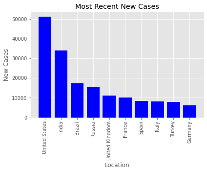

```python
mostrecentnewcases = pandasql.sqldf("SELECT * FROM mostrecentnoconts ORDER BY new_cases DESC LIMIT 10")

#print(mostrecentnewcases)

plt.style.use('ggplot')

xnew = mostrecentnewcases["location"]
newcases = mostrecentnewcases["new_cases"]

x_posnew = [i for i, _ in enumerate(xnew)]

plt.bar(x_posnew, newcases, color='blue')
plt.xlabel("Location")
plt.ylabel("New Cases")
plt.title("Most Recent New Cases")
plt.tight_layout()
plt.xticks(x_pos, x, rotation=90)


plt.show()
```

For the time being I think I am satisfied with how these graphs came out. For the next part I want to graph a couple countries over time, and then I would like to compare some countries graphs based on the metrics provided. I am interested to see how much of a difference there is when comparing things like GDP, hand washing stations, amount of smokers. Obviously the causes of the differences are beyond what I can explore, but I would like to think this excercise might be somewhat relevant.

```python
#To start I need to restart with the original data set, I will have to pull a single country. Because I am more familiar with the united states covid graphs already, Ill be using that data

usasql = pandasql.sqldf("SELECT * FROM covidset WHERE iso_code IS 'USA'")
```

Now I want to make a plot of daily new cases over time

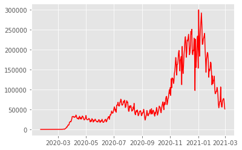

```python
newcasesdaily = pandasql.sqldf("SELECT new_cases, date FROM usasql")
usadates = newcasesdaily['date']
usadatesnewcases = [datetime.datetime.strptime(d, '%Y-%m-%d').date() for d in usadates]

#print(usadatesnewcases)

plt.plot(usadatesnewcases, newcasesdaily['new_cases'], color="red")

plt.show()
```

Comparing to the 7-day moving average from CDC.gov this looks to be fairly accurate. Now I must make a function that does this process to speed things up.

```python
def newdaily(countryiso):
    torun = "SELECT * FROM covidset WHERE iso_code IS '" + countryiso + "'"
    sqldatanewcountry = pandasql.sqldf(torun)
    countrynew = pandasql.sqldf("SELECT new_cases, date FROM sqldatanewcountry")
    countrynewdates = usadatesnewcases = [datetime.datetime.strptime(d, '%Y-%m-%d').date() for d in countrynew['date']]

    plt.plot(countrynewdates, countrynew['new_cases'], label=countryiso)
```

```python
def newdailysmooth(countryiso):
    torun = "SELECT * FROM covidset WHERE iso_code IS '" + countryiso + "'"
    sqldatanewcountry = pandasql.sqldf(torun)
    countrynew = pandasql.sqldf("SELECT new_cases_smoothed, date FROM sqldatanewcountry")
    countrynewdates = usadatesnewcases = [datetime.datetime.strptime(d, '%Y-%m-%d').date() for d in countrynew['date']]

    plt.plot(countrynewdates, countrynew['new_cases_smoothed'], label=countryiso)
```

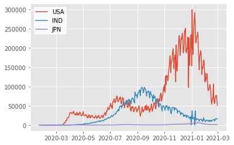

```python
newdaily('USA')
newdaily('IND')
newdaily('JPN')
legend = plt.legend(loc="upper left")
legend.get_frame().set_facecolor('white')
```

I had thought that looking in the difference in the curves provided by countries with high or low gdp per capita would be an interesting test.

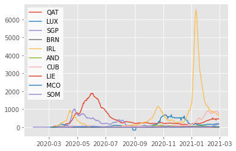

```python
topGDPcountries = pandasql.sqldf("SELECT iso_code FROM mostrecentnoconts ORDER BY gdp_per_capita DESC LIMIT 5")
lowGDPcountries = pandasql.sqldf("SELECT iso_code FROM mostrecentnoconts ORDER BY gdp_per_capita ASC LIMIT 5")

for i in topGDPcountries['iso_code']:
    newdailysmooth(i)

for ii in lowGDPcountries['iso_code']:
    newdailysmooth(ii)

legend = plt.legend()
legend.get_frame().set_facecolor('white')
```

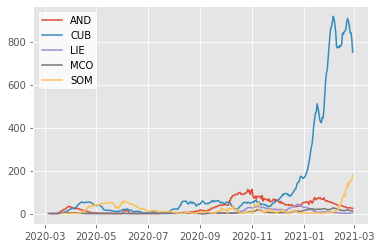

```python
for ii in lowGDPcountries['iso_code']:
    newdailysmooth(ii)

legend = plt.legend()
legend.get_frame().set_facecolor('white')
```

Now I want to get a better idea of correlation between some of the different pieces of information given. I think the easiest/most realistic way for me to approach this would be to return to the single latest total amount of cases, as I dont have the means to process so many individual daily points of data. For this I want to make use of numpy and pandas built in correlation features, which hopefully gives some neat insights.

```python
#going back to just the most recent total cases we will use pandas corr function to each column.
mostrecentnocontsFloats = mostrecentnoconts.select_dtypes(include=['float64'])
mostrecentnocontsFloats.replace('',np.nan,inplace=True)

correlationvalues = dict()
for col in mostrecentnocontsFloats.columns[3:]:
    #print(mostrecentnocontsFloats[col])
    correlationvalues[col] = mostrecentnoconts["total_cases"].corr(mostrecentnoconts[col])

print(correlationvalues)
```

```
{'total_deaths': 0.9572172761923727, 'new_deaths': 0.8765062324399985, 'new_deaths_smoothed': 0.9019397622891673, 'total_cases_per_million': 0.24350167259713837, 'new_cases_per_million': 0.05847464993745234, 'new_cases_smoothed_per_million': 0.08142694267486315, 'total_deaths_per_million': 0.2868995…
```

Got a cool dictionary of the correlation for various attributes alongside the total cases of the country. So now we want to see what has the highest and what has the closest to 1 and -1.

```python
corrvalinverted = {v: k for k, v in correlationvalues.items()}
corrvalinvertedsorted = sorted(corrvalinverted)
corrvalinvertedsorted = corrvalinvertedsorted[:-5] #Removing nan values
print(corrvalinvertedsorted)
```

```
[-0.1318419312774545, -0.1270102321911266, -0.07996413416901155, -0.027194805027679902, 0.01726533612992128, 0.038546451938612586, 0.05847464993745234, 0.08142694267486315, 0.10328183794759874, 0.11274558823878071, 0.13328155136364864, 0.13685678249255823, 0.16087023021914723, 0.16863029034879568, 0…
```

```python
topposcorr = corrvalinvertedsorted[-15:]
print("Highest Correlation Values")
for val in topposcorr:
    print(f"{val} at {corrvalinverted[val]}")
topnegcorr = corrvalinvertedsorted[:5]
print("\nLowest Correlation Values:")
for val in topnegcorr:
    print(f"{val} at {corrvalinverted[val]}")
```

```
Highest Correlation Values
0.038546451938612586 at diabetes_prevalence
0.05847464993745234 at new_cases_per_million
0.08142694267486315 at new_cases_smoothed_per_million
0.10328183794759874 at handwashing_facilities
0.11274558823878071 at new_deaths_per_million
0.13328155136364864 at female_smokers
0.13685678249255823 at life_expectancy
0.16087023021914723 at gdp_per_capita
0.16863029034879568 at median_age
0.16926073097593516 at aged_70_older
0.1749139466009176 at aged_65_older
0.1851613009820853 at human_development_index
0.20793281194961352 at new_deaths_smoothed_per_million
0.24350167259713837 at total_cases_per_million
0.28689951902254196 at total_deaths_per_million

Lowest Correlation Values:
-0.1318419312774545 at cardiovasc_death_rate
-0.1270102321911266 at extreme_poverty
-0.07996413416901155 at male_smokers
-0.027194805027679902 at population_density
0.01726533612992128 at hospital_beds_per_thousand
```